# Datenvisualisierung mit R

Übungsaufgabe

Armin Schäfer

schaefer@politik.uni-mainz.de

22.05.2025

Ihre Aufgabe besteht darin, die folgende Grafik selbst zu erstellen. Hinweise folgen auf den nächsten Seiten.

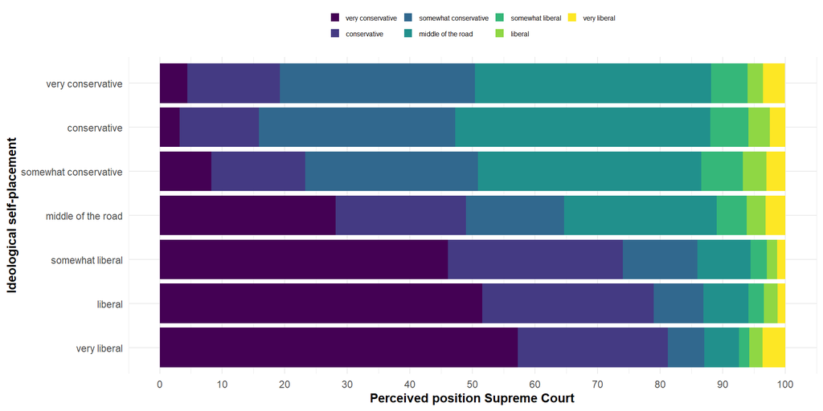

## YAML ergänzen

Wenn Sie das Quarto-Dokument als PDF-Datei erstellen möchten, müssen Sie die Präambel anpassen (“YAML”). Bisher haben wir ein html-Dokument erstellt, doch jetzt wechseln Sie zu PDF:

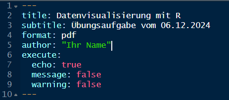

## Datensatz

Der Datensatz, den Sie verwenden werden, ist ein kleiner Ausschnitt aus der [Cooperative Election Study](https://cces.gov.harvard.edu/), die eine Fülle von Fragen zu US-amerikanischer Politik enhält. Die Studie zeichnet sich durch eine besonders hohe Anzahl von Befragten aus, weil zum Teil Analysen auf regionaler oder sogar bundesstaatlicher Ebene vorgenommen werden.

Sie finden die Datei unter dem Namen ces_usa.csv im Ordner “Datensätze” in Moodle. Dort ist auch ein Auszug aus dem Codebuch hinterlegt, den Sie für die Bearbeitung benötigen werden.

## Codieren

Fast alle Arbeitsschritte, die Sie vornehmen müssen, haben wir bereits behandelt – und trotzdem ist es vermutlich nicht einfach, diese Grafik zu erstellen. Sie dürfen alle Hilfsmittel verwenden und falls nicht alles klappt, ist es nicht schlimm.

Beachten Sie, dass es im Datensatz fehlende Werte gibt und dass die Faktorenlevel der verwendeten Spalten angepasst werden müssen (siehe Codebuch).

Die Farben habe ich nicht per Hand hinzugefügt, sondern mithilfe der Farbpalette `viridis`, für die es einen eigenen `scale_fill...`-Befehl gibt.

## Abgabetermin

Bitte laden Sie ihre Lösung als PDF-Dokument im entsprechenden Ordner bis zum **02.06. (18:00 Uhr)** in Moodle hoch, *selbst wenn Sie nicht alle Details hinbekommen haben*.

Ab 18:00 Uhr stelle ich eine Musterlösung zur Verfügung, die Ihren Kenntnisstand spiegelt. Später werden wir lernen, wie sich das Skript durch Funktionen vereinfachen (?!) lässt.

[figure not shown]